# Ch 5: Linear Models

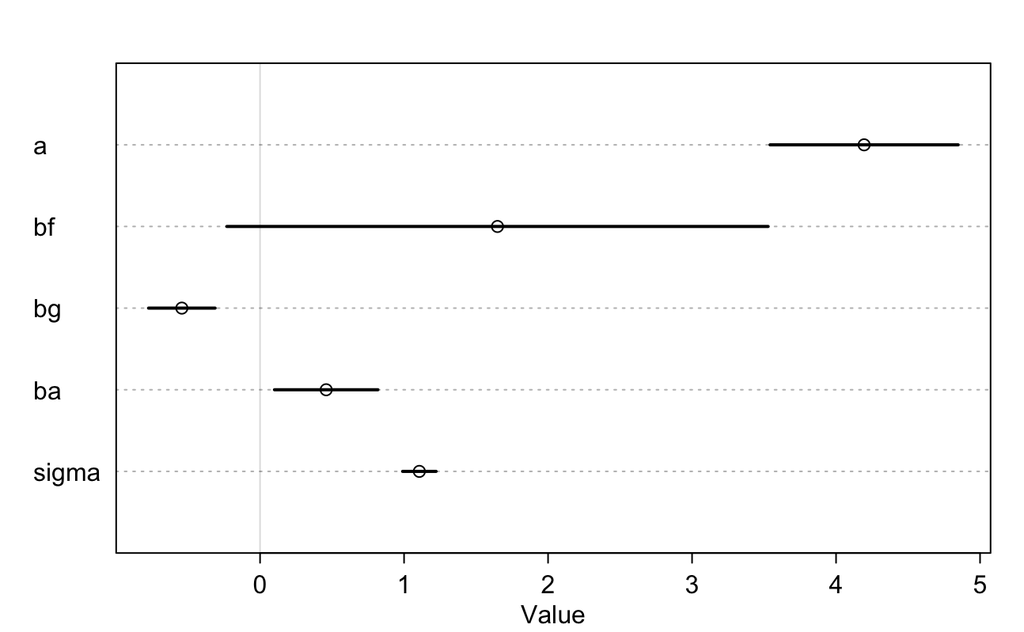

```r
# weight ~ avgfood + groupsize + area
m5h3b <- rethinking::map(
  alist(
    weight ~ dnorm(mu, sigma),
    mu <- a + bf * avgfood + bg * groupsize + ba * area,
    a ~ dnorm(0, 10),
    c(bf, bg, ba) ~ dnorm(0, 2),
    sigma ~ dunif(0, 10)
  ),
  data = foxes
)

plot(precis(m5h3b))
```

`area` and `avgfood` are highly correlated (0.88), so the amount of information about weight you get from knowing `area` is reduced if you already know `avgfood` and vice versa. Comparing the models $weight \sim area + groupsize$ and $weight \sim avgfood + groupsize$ removes the masking relationship and lets us assess the relative merit of `area` and `avgfood`. When controlling for `groupsize`, increasing `avgfood` by one standard deviation on average increases weight by a factor of 14.073533, which is much greater than increasing `area` by a standard deviation (0.658878). However, the uncertainty in the relationship is also much greater. It may help to standardize the variables first before fitting the model. After doing so, we see `avgfood` has a steeper slope but less certainty. As a result, the width of the prediction interval (from `sim()`, not `link()`) is greater. On that basis, I would include `area`.

```r
zscore <- function(x) (x - mean(x)) / sd(x)
d <- foxes %>%
  mutate_at(vars(avgfood, area, groupsize), list(z = zscore))

m5h2z <- rethinking::map(
  alist(
    weight ~ dnorm(mu, sigma),
    mu <- a + ba * area_z + bg * groupsize_z,
    a ~ dnorm(0, 10),
    c(ba, bg) ~ dnorm(0, 2),
    sigma ~ dunif(0, 10)
  ),
  data = d
)

m5h3az <- rethinking::map(
  alist(
    weight ~ dnorm(mu, sigma),
    mu <- a + bf * avgfood_z + bg * groupsize_z,
    a ~ dnorm(0, 10),
    c(bf, bg) ~ dnorm(0, 2),
    sigma ~ dunif(0, 10)
  ),
  data = d
)

precis(m5h2z)
```

|  | mean | sd | 5.5% | 94.5% |
| --- | --- | --- | --- | --- |
| a | 4.53 | 0.10 | 4.36 | 4.70 |
| ba | 0.56 | 0.18 | 0.27 | 0.86 |
| bg | -0.66 | 0.18 | -0.95 | -0.36 |
| sigma | 1.12 | 0.07 | 1.00 | 1.24 |

```r
precis(m5h3az)
```

|  | mean | sd | 5.5% | 94.5% |
| --- | --- | --- | --- | --- |
| a | 4.53 | 0.10 | 4.36 | 4.69 |
| bf | 0.74 | 0.24 | 0.36 | 1.12 |
| bg | -0.85 | 0.24 | -1.23 | -0.47 |
| sigma | 1.12 | 0.07 | 1.00 | 1.23 |

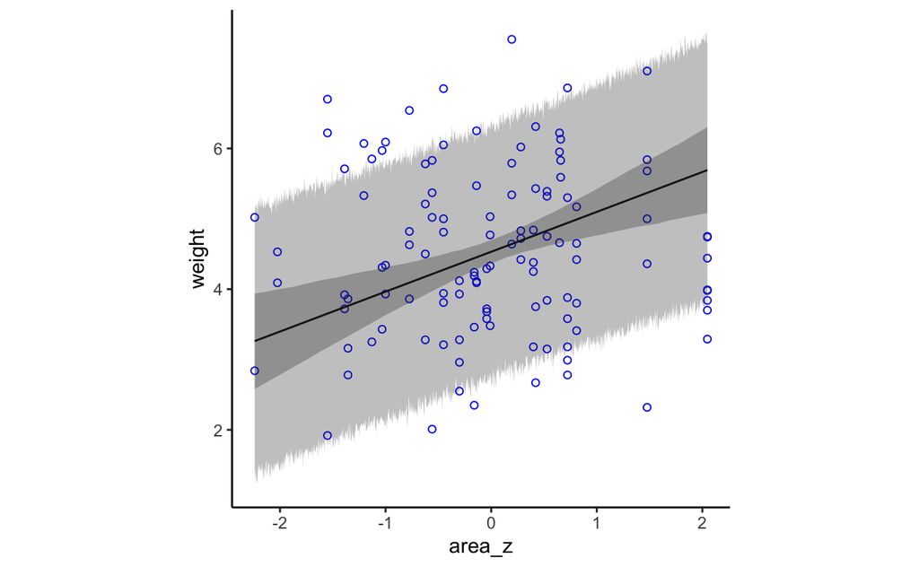

```r
N <- 1000
# area_z
x <- seq(min(d$area_z), max(d$area_z), length.out = N)
linkx <- link(m5h2z, tibble(area_z = x, groupsize_z = 0))
simx <- sim(m5h2z, tibble(area_z = x, groupsize_z = 0))
pred.data1 <- tibble(
  x,
  mu = apply(linkx, 2, mean),
  mu.low = apply(linkx, 2, PI)[1, ],
  mu.hi = apply(linkx, 2, PI)[2, ],
  y.low = apply(simx, 2, PI)[1, ],
  y.hi = apply(simx, 2, PI)[2, ],
)

ggplot(d, aes(area_z, weight)) +
  geom_point(shape = 21, color = "blue") +
  geom_line(aes(x, mu), pred.data1, inherit.aes = FALSE) +
  geom_ribbon(aes(x, ymin = mu.low, ymax = mu.hi),
              pred.data1,
              inherit.aes = FALSE,
              alpha = 0.3) +
  geom_ribbon(aes(x, ymin = y.low, ymax = y.hi),
              pred.data1,
              inherit.aes = FALSE,
              alpha = 0.3) +
  theme_classic() +
  theme(aspect.ratio = 1)
```

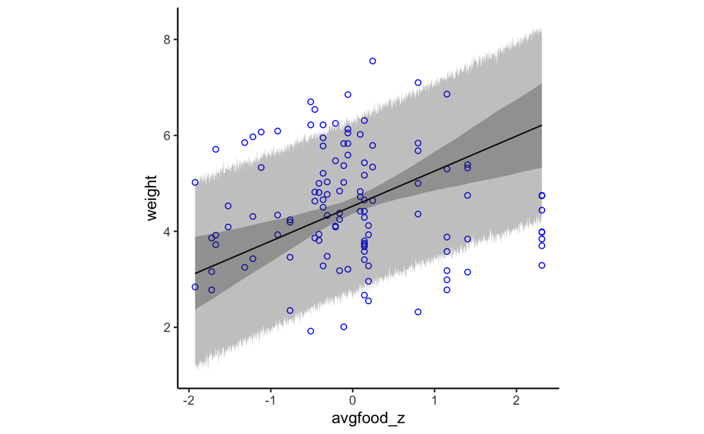

```r
# avgfood_z
x <- seq(min(d$avgfood_z), max(d$avgfood_z), length.out = N)
linkx <- link(m5h3az, tibble(avgfood_z = x, groupsize_z = 0))
simx <- sim(m5h3az, tibble(avgfood_z = x, groupsize_z = 0))
pred.data2 <- tibble(
  x,
  mu = apply(linkx, 2, mean),
  mu.low = apply(linkx, 2, PI)[1, ],
  mu.hi = apply(linkx, 2, PI)[2, ],
  y.low = apply(simx, 2, PI)[1, ],
  y.hi = apply(simx, 2, PI)[2, ],
)

ggplot(d, aes(avgfood_z, weight)) +
  geom_point(shape = 21, color = "blue") +
  geom_line(aes(x, mu), pred.data2, inherit.aes = FALSE) +
  geom_ribbon(aes(x, ymin = mu.low, ymax = mu.hi),
              pred.data2,
              inherit.aes = FALSE,
              alpha = 0.3) +
  geom_ribbon(aes(x, ymin = y.low, ymax = y.hi),
              pred.data2,
              inherit.aes = FALSE,
              alpha = 0.3) +
  theme_classic() +
  theme(aspect.ratio = 1)
```